# Introduction

Python環境の構築を行います．既にPythonを実行できる環境にある方は読み飛ばしてください．

# 概要

1. Python(anaconda)のインストール
2. 仮想環境の作成,立ち上げ

   1.AnacondaNavigatorの起動

   2.仮想環境の作成
3. Jupyter Labのインストール
4. 実行とモジュールのインストール

### 1. Python(anaconda)のインストール

#### Anacondaとは？

「Anacondaとは、Pythonでプログラムを作成する際によく用いられる，**複数のライブラリを、1つのパッケージとして一括で管理・インストール することができる**ディストリビューションのことです。」[insource](https://www.insource.co.jp/python-gakuin/mail-backnumber/vol22.html)より

※ディストリビューション:複数のソフトウェアやツールなどを、ひとつのパッケージにしたもののこと。

つまりは，「**データサイセエンスでよく利用されるライブラリが付属したPythonで，環境の構築と管理が便利！**」程度の認識でOKです．

[ANACONDA公式](https://www.anaconda.com/products/distribution)から，自身のPCにあったダウンロードしてください．

> 参考

> [Python Japan Windows版Anacondaのインストール](https://www.python.jp/install/anaconda/windows/install.html)

> [Python Japan MacOS版Anacondaのインストール](https://www.python.jp/install/anaconda/macos/install.html)

#### 2. 仮想環境の作成,立ち上げ

「Pythonを使って開発や実験を行うときは、用途に応じて専用の実行環境を作成し、切り替えて使用するのが一般的です。 こういった、一時的に作成する実行環境を、「仮想環境」 と言います.」Python Japan 仮想環境より

AnacondaではAnacondaNavigatorからGUI操作で仮想環境を作成することができます．

1. AnacondaNavigatorの起動

AnacondaNavigator起動して，Environmentを選択します．デフォルトではbase(root)のみ存在しています．(私の場合はbase以外に作成済みの環境pytorch,ramanの2つがあります)

[figure not shown]

1. 仮想環境の作成

Createをクリックし，nameに「myenv」と入力(名前は任意)し，Pythonのverを指定(選択できるバージョンが少ないかもしれませんが，3.~のPythonであればOKです．)して，Createをクリックします．

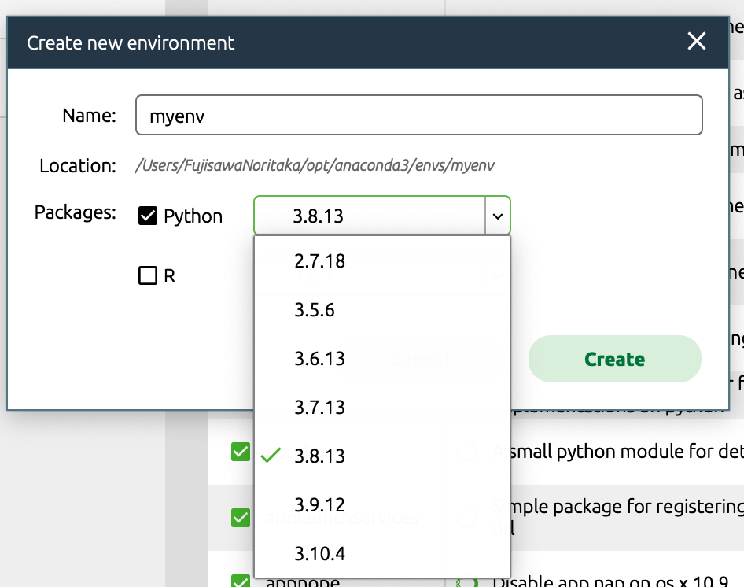

環境が構築されると，listにmyenvが追加されます．再生マークをクリックして，open terminalをクリックすることで，myenvが利用できるターミナル(WindowsならPowerShellかも)を開きます．(後で利用します)．今回は先にJupyterLabインストールします．

[figure not shown]

### 3. JupyterLabのインストール

Homeをクリックして，「Applicatoin on」が「myenv」であることを確認の上，JupyterLabのinstallをクリックします． installを終えると，代わりに「Launch」がクリックできるようになりますので，クリックします． ブラウザが立ち上がり，JupyterLabが起動されれば，OKです．

> JupyterLab は、コード、データ、そして Jupyter Notebook のファイル形式（*.ipynb）を扱う最新の対話型開発環境（IDE）です。 Jupyter Notebook 同様、オープンソースとして公開されています

[figure not shown]

### 4. 実行とモジュールのインストール

JupyterLabの左に表示されるフォルダの一覧から，「0_create_simulated_spectra.ipynb」を開いてみます．実行は右三角マークです． JupyterLabではセルと呼ばれる単位で上からコードを実行できます．右三角マークを2度押しましょう．(三角2つマークで先頭から全て実行することもできます．)

[figure not shown]

エラーが発生しています．「ModuleNotFoundError: No module named 'numpy'」

これは，importしたいmodule,今回はnumpyが無いためです．モジュールのinstallにはconda installコマンドを実行する必要があります． 基本的に「conda install (モジュール名)」でググれば，[Anacondaの公式](https://anaconda.org/anaconda/numpy)サイトが出てきますので，「To install this package with conda run:」以降の灰色の箇所，今回であれば，「conda install -c anaconda numpy」をコピーします．

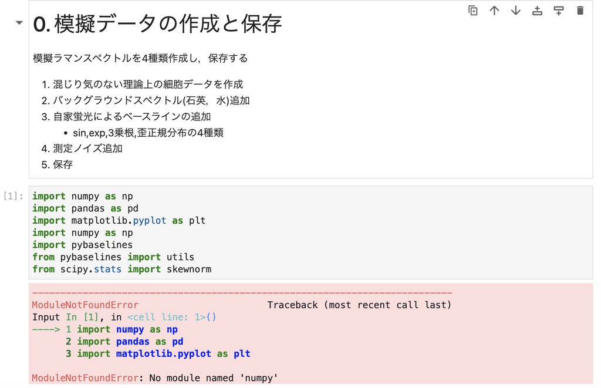

先ほど開いておいた，myenv環境のターミナル(もしくはPowerShellなど)に，「conda install -c anaconda numpy」を貼り付けて,Enterを押して，installします．「Proceed ([y]/n)? 」と確認されたら，Enterを押して，続行します． なお，先頭の(myenv)が「このターミナルはmyenv環境がアクティブですよ」と教えてくれています．

[figure not shown]

Preparing transaction: done  
Verifying transaction: done  
Executing transaction: done  
と表示されれば，install成功です．

JupyterLabに戻り．三角2つマークをクリックして再度実行します．「Restart Kernel?」と表示され，「Restart」を選択すると，先頭から再実行できます．

すると，「ModuleNotFoundError: No module named 'pandas'」と表示されました． 先ほどと同様に,「conda install pandas」とググって,anacondaの公式ドキュメントからinstallコマンドをコピー，ターミナルに貼り付けて，必要なモジュールをinstallしていきます．後は調べながらインストールしてみてください．(一応,「参考」にインストールコマンドを用意しておきます)

これで，Anacondaを利用したPython実行環境の構築は終了です． 以降は,「1_remove_background.ipynb」から順にコードを読んで実行して見てください．

なお，JupyterLabの終了は「File」から「Shut Down」です．

### 参考 : 利用するモジュールとその説明

- numpy : conda install -c anaconda numpy

効率的な数値計算を行うための型付きの多次元配列のサポートをPythonに加えるとともに、それらを操作するための大規模な高水準の数学関数ライブラリを提供

- pandas : conda install -c anaconda pandas

数表および時系列データを操作するためのデータ構造と演算を提供

- matplotlib : conda install -c conda-forge matplotlib

NumPyのためのグラフ描画ライブラリ

- pybaselines : conda install -c conda-forge pybaselines

実験データのベースライン補正を行うためのライブラリ

- scikit-learn(sklarn) : conda install -c anaconda scikit-learn

Python用の機械学習ライブラリ．PCAなどもある．

- scipy : conda install -c anaconda scipy

プログラミング数学、科学、工学のための数値解析ソフトウェア

その他,は個人が必要に応じて，インストールしてください．